# AIML_ML_Project_full_code_notebook

## Problem Statement

### Context

AllLife Bank is a US bank that has a growing customer base. The majority of these customers are liability customers (depositors) with varying sizes of deposits. The number of customers who are also borrowers (asset customers) is quite small, and the bank is interested in expanding this base rapidly to bring in more loan business and in the process, earn more through the interest on loans. In particular, the management wants to explore ways of converting its liability customers to personal loan customers (while retaining them as depositors).

A campaign that the bank ran last year for liability customers showed a healthy conversion rate of over 9% success. This has encouraged the retail marketing department to devise campaigns with better target marketing to increase the success ratio.

You as a Data scientist at AllLife bank have to build a model that will help the marketing department to identify the potential customers who have a higher probability of purchasing the loan.

### Objective

To predict whether a liability customer will buy personal loans, to understand which customer attributes are most significant in driving purchases, and identify which segment of customers to target more.

### Data Dictionary

- `ID`: Customer ID
- `Age`: Customer’s age in completed years
- `Experience`: #years of professional experience
- `Income`: Annual income of the customer (in thousand dollars)
- `ZIP Code`: Home Address ZIP code.
- `Family`: the Family size of the customer
- `CCAvg`: Average spending on credit cards per month (in thousand dollars)
- `Education`: Education Level. 1: Undergrad; 2: Graduate;3: Advanced/Professional
- `Mortgage`: Value of house mortgage if any. (in thousand dollars)
- `Personal_Loan`: Did this customer accept the personal loan offered in the last campaign? (0: No, 1: Yes)
- `Securities_Account`: Does the customer have securities account with the bank? (0: No, 1: Yes)
- `CD_Account`: Does the customer have a certificate of deposit (CD) account with the bank? (0: No, 1: Yes)
- `Online`: Do customers use internet banking facilities? (0: No, 1: Yes)
- `CreditCard`: Does the customer use a credit card issued by any other Bank (excluding All life Bank)? (0: No, 1: Yes)

```python
from google.colab import drive
drive.mount('/content/drive')
```

## Importing necessary libraries

```python
# ignoring warnings
import warnings
warnings.filterwarnings("ignore")
```

```python
# Installing the libraries with the specified version.
!pip install numpy==1.26.4 pandas==2.2.2 matplotlib==3.8.0 seaborn==0.13.1 scikit-learn==1.3.2 sklearn-pandas==2.2.0 -q --user
```

**Note**:

1. After running the above cell, kindly restart the notebook kernel (for Jupyter Notebook) or runtime (for Google Colab), write the relevant code for the project from the next cell, and run all cells sequentially from the next cell.
2. On executing the above line of code, you might see a warning regarding package dependencies. This error message can be ignored as the above code ensures that all necessary libraries and their dependencies are maintained to successfully execute the code in this notebook.

```python
# Data manipulation and analysis
import pandas as pd
import numpy as np

# Visualization
import matplotlib.pyplot as plt
import seaborn as sns

# Machine Learning Algorithms
from sklearn.linear_model import LogisticRegression
from sklearn.tree import DecisionTreeClassifier

# Model Evaluation
from sklearn.model_selection import train_test_split, GridSearchCV, cross_val_score
from sklearn.metrics import (confusion_matrix, classification_report,
                             roc_curve, roc_auc_score, accuracy_score)
from sklearn.preprocessing import StandardScaler

# Ignore warnings
import warnings
warnings.filterwarnings('ignore')
```

## Loading the dataset

```python
#making local directory as default directory
%cd "/content/drive/MyDrive/PGP_AI_ML_AUSTIN_NOV_2024/Project-2: Regression and Classification"
```

```
/content/drive/MyDrive/PGP_AI_ML_AUSTIN_NOV_2024/Project-2: Regression and Classification
```

## Data Overview

- Observations
- Sanity checks

```python
data = pd.read_csv('Loan_Modelling.csv')
```

```python
# Before doing any operations on the data frame, let's keep a copy so that original data frame will be intact

data_original = data.copy()
```

```python
#View first 5 records to understand basic structure
data.head()
```

|  | ID | Age | Experience | Income | ZIPCode | Family | CCAvg | Education | Mortgage | Personal_Loan | Securities_Account | CD_Account | Online | CreditCard |
| --- | --- | --- | --- | --- | --- | --- | --- | --- | --- | --- | --- | --- | --- | --- |
| 0 | 1 | 25 | 1 | 49 | 91107 | 4 | 1.6 | 1 | 0 | 0 | 1 | 0 | 0 | 0 |
| 1 | 2 | 45 | 19 | 34 | 90089 | 3 | 1.5 | 1 | 0 | 0 | 1 | 0 | 0 | 0 |
| 2 | 3 | 39 | 15 | 11 | 94720 | 1 | 1.0 | 1 | 0 | 0 | 0 | 0 | 0 | 0 |
| 3 | 4 | 35 | 9 | 100 | 94112 | 1 | 2.7 | 2 | 0 | 0 | 0 | 0 | 0 | 0 |
| 4 | 5 | 35 | 8 | 45 | 91330 | 4 | 1.0 | 2 | 0 | 0 | 0 | 0 | 0 | 1 |

```python
#Number of rows and columns in the "data" frame
data.shape
```

```
(5000, 14)
```

```python
# To understand the distribution of the loan_data in terms of summary statistics for all columns and transposing for the display format
data.describe(include='all').T
```

|  | count | mean | std | min | 25% | 50% | 75% | max |
| --- | --- | --- | --- | --- | --- | --- | --- | --- |
| ID | 5000.0 | 2500.500000 | 1443.520003 | 1.0 | 1250.75 | 2500.5 | 3750.25 | 5000.0 |
| Age | 5000.0 | 45.338400 | 11.463166 | 23.0 | 35.00 | 45.0 | 55.00 | 67.0 |
| Experience | 5000.0 | 20.104600 | 11.467954 | -3.0 | 10.00 | 20.0 | 30.00 | 43.0 |
| Income | 5000.0 | 73.774200 | 46.033729 | 8.0 | 39.00 | 64.0 | 98.00 | 224.0 |
| ZIPCode | 5000.0 | 93169.257000 | 1759.455086 | 90005.0 | 91911.00 | 93437.0 | 94608.00 | 96651.0 |
| Family | 5000.0 | 2.396400 | 1.147663 | 1.0 | 1.00 | 2.0 | 3.00 | 4.0 |
| CCAvg | 5000.0 | 1.937938 | 1.747659 | 0.0 | 0.70 | 1.5 | 2.50 | 10.0 |
| Education | 5000.0 | 1.881000 | 0.839869 | 1.0 | 1.00 | 2.0 | 3.00 | 3.0 |
| Mortgage | 5000.0 | 56.498800 | 101.713802 | 0.0 | 0.00 | 0.0 | 101.00 | 635.0 |
| Personal_Loan | 5000.0 | 0.096000 | 0.294621 | 0.0 | 0.00 | 0.0 | 0.00 | 1.0 |
| Securities_Account | 5000.0 | 0.104400 | 0.305809 | 0.0 | 0.00 | 0.0 | 0.00 | 1.0 |
| CD_Account | 5000.0 | 0.060400 | 0.238250 | 0.0 | 0.00 | 0.0 | 0.00 | 1.0 |
| Online | 5000.0 | 0.596800 | 0.490589 | 0.0 | 0.00 | 1.0 | 1.00 | 1.0 |
| CreditCard | 5000.0 | 0.294000 | 0.455637 | 0.0 | 0.00 | 0.0 | 1.00 | 1.0 |

### Summary of Variables Classification (Ordinal, Nominal, Categorical and Numerical)

#### Numerical Variables

Continuous Numerical Variables (can take any value within the range):

#### Income

#### CCAvg

#### Mortgage

Discrete Numerical Variables (can take specific integer value):

#### Age

#### Experience

#### Family

#### Categorical Variables

Ordinal Variables (Categorical Variables with natural order):

#### Education

Nominal Variables (Categorical Variables without any natural order):

#### ZIP Code

#### Personal_Loan

#### Securities_Account

#### CD_Account

#### Online

#### CreditCard

#### Observations on Data Distribution:

#### Age

Mean and Median: As the mean and median ages are close (45.33, 45), the age distribution is symmetric/normal distribution

#### Income

Mean vs. Median: As a significant difference between Mean and Median suggest that Income data is right-skewed. Standard Deviation: High value indicates diverse income levels among customers.

#### ZIP Code:

Zip code column is not having any predictive value, this column will be dropped from the model.

#### Family:

Family column ranges from 1 to 4, represents an ordinal Categorical column.

#### CCAVG: (Average Monthly Credit Card Spending)

Mean and Median: A higher mean (1.93) than median (1.5) indicates a right-skewed distribution with some high spenders. Additionally, 75% of individuals in the dataset spend less than $2,500

#### Personal_Loan:

The mean value gives the overall acceptance rate (customers acceptance rate from previous campaign). it's value is 0.09 which means there are only ~ 10% of the customers who accepted the loan. There is Class Imbalance for this column.

#### Securities_Account, CD_Account, Online Account:

Securities_Account: There are only ~10% of csutomers who has Securities Account with All Life Bank. CD_Account: There are only ~6% of csutomers who has CD Account with All Life Bank. Online(Account): High Usage (59% of the customers) suggests customers are comfortable doing business with the help of digital platforms. This also indicates that these customers may be more responsive to digital marketing.

#### Credit Card:

Percentage Using Other Banks' Cards: 29% of the customers having other bank's credit card which indicate these customers' openness to multiple banking relationships. That means these are potential customers to promote All Life Bank credit card's.

```python
data.info()
```

```
<class 'pandas.core.frame.DataFrame'>
RangeIndex: 5000 entries, 0 to 4999
Data columns (total 14 columns):
 #   Column              Non-Null Count  Dtype
---  ------              --------------  -----
 0   ID                  5000 non-null   int64
 1   Age                 5000 non-null   int64
 2   Experience          5000 non-null   int64
 3   Income              5000 non-null   int64
 4   ZIPCode             5000 non-null   int64
 5   Family              5000 non-null   int64
 6   CCAvg               5000 non-null   float64
 7   Education           5000 non-null   int64
 8   Mortgage            5000 non-null   int64
 9   Personal_Loan       5000 non-null   int64
 10  Securities_Account  5000 non-null   int64
 11  CD_Account          5000 non-null   int64
 12  Online              5000 non-null   int64
 13  CreditCard          5000 non-null   int64
dtypes: float64(1), int64(13)
memory usage: 547.0 KB
```

```python
# list of columns
data.columns
```

```
Index(['ID', 'Age', 'Experience', 'Income', 'ZIPCode', 'Family', 'CCAvg',
       'Education', 'Mortgage', 'Personal_Loan', 'Securities_Account',
       'CD_Account', 'Online', 'CreditCard'],
      dtype='object')
```

```python
#Check for duplicates
data.duplicated().sum()
```

```
0
```

```python
data.isna().sum()
```

|  | 0 |
| --- | --- |
| ID | 0 |
| Age | 0 |
| Experience | 0 |
| Income | 0 |
| ZIPCode | 0 |
| Family | 0 |
| CCAvg | 0 |
| Education | 0 |
| Mortgage | 0 |
| Personal_Loan | 0 |
| Securities_Account | 0 |
| CD_Account | 0 |
| Online | 0 |
| CreditCard | 0 |

**dtype:** int64

#### There are no duplicates in the dataset and no null values across all columns. Data is clean

## Data Preprocessing

- Missing value treatment
- Feature engineering (if needed)
- Outlier detection and treatment (if needed)
- Preparing data for modeling
- Any other preprocessing steps (if needed)

### **Steps for fixing Data Quality issue for the Experience column data**

#### 1. Determining how many negative values are present

#### 2. Identify the Affected Records

#### 3. Approach to be followed

```python
#1. Determining how many negative values are present
negative_experience = data[data['Experience'] < 0]
num_negative = len(negative_experience)
total_records = len(data)
print("Number of negative values in the 'Experience' column:", num_negative)
percentage_negative = (num_negative / total_records) * 100
print("Percentage of negative values in the 'Experience' column:", percentage_negative)
```

```
Number of negative values in the 'Experience' column: 52
Percentage of negative values in the 'Experience' column: 1.04
```

```python
#2. Identify the Affected Records
print(negative_experience.head(5))
```

```
      ID  Age  Experience  Income  ZIPCode  Family  CCAvg  Education  \
89    90   25          -1     113    94303       4   2.30          3
226  227   24          -1      39    94085       2   1.70          2
315  316   24          -2      51    90630       3   0.30          3
451  452   28          -2      48    94132       2   1.75          3
524  525   24          -1      75    93014       4   0.20          1

     Mortgage  Personal_Loan  Securities_Account  CD_Account  Online  \
89          0              0                   0           0       0
226         0              0                   0           0       0
315         0              0                   0           0       1
451        89              0                   0           0       1
524         0              0                   0           0       1

     CreditCard
89            1
226           0
315           0
451           0
524           0
```

#### 3.Options to fix negative values for the Experience column:

#### Option 1: Drop records with Negative Experience values

#### Option 2: Correct Negative Values by Taking Absolute Values

```python
#Option 1: Drop records with Negative Experience values
data_cleaned = data[data['Experience'] >= 0].copy()
```

#### **Decision on which Option to choose**:

```python
#Proceed with Option 2:
# Correct the negative sign for Experience by taking absolute values
data['Experience'] = data['Experience'].abs()
```

```python
data.describe(include='all').T
```

|  | count | mean | std | min | 25% | 50% | 75% | max |
| --- | --- | --- | --- | --- | --- | --- | --- | --- |
| ID | 5000.0 | 2500.500000 | 1443.520003 | 1.0 | 1250.75 | 2500.5 | 3750.25 | 5000.0 |
| Age | 5000.0 | 45.338400 | 11.463166 | 23.0 | 35.00 | 45.0 | 55.00 | 67.0 |
| Experience | 5000.0 | 20.134600 | 11.415189 | 0.0 | 10.00 | 20.0 | 30.00 | 43.0 |
| Income | 5000.0 | 73.774200 | 46.033729 | 8.0 | 39.00 | 64.0 | 98.00 | 224.0 |
| ZIPCode | 5000.0 | 93169.257000 | 1759.455086 | 90005.0 | 91911.00 | 93437.0 | 94608.00 | 96651.0 |
| Family | 5000.0 | 2.396400 | 1.147663 | 1.0 | 1.00 | 2.0 | 3.00 | 4.0 |
| CCAvg | 5000.0 | 1.937938 | 1.747659 | 0.0 | 0.70 | 1.5 | 2.50 | 10.0 |
| Education | 5000.0 | 1.881000 | 0.839869 | 1.0 | 1.00 | 2.0 | 3.00 | 3.0 |
| Mortgage | 5000.0 | 56.498800 | 101.713802 | 0.0 | 0.00 | 0.0 | 101.00 | 635.0 |
| Personal_Loan | 5000.0 | 0.096000 | 0.294621 | 0.0 | 0.00 | 0.0 | 0.00 | 1.0 |
| Securities_Account | 5000.0 | 0.104400 | 0.305809 | 0.0 | 0.00 | 0.0 | 0.00 | 1.0 |
| CD_Account | 5000.0 | 0.060400 | 0.238250 | 0.0 | 0.00 | 0.0 | 0.00 | 1.0 |
| Online | 5000.0 | 0.596800 | 0.490589 | 0.0 | 0.00 | 1.0 | 1.00 | 1.0 |
| CreditCard | 5000.0 | 0.294000 | 0.455637 | 0.0 | 0.00 | 0.0 | 1.00 | 1.0 |

## Exploratory Data Analysis.

- EDA is an important part of any project involving data.
- It is important to investigate and understand the data better before building a model with it.
- A few questions have been mentioned below which will help you approach the analysis in the right manner and generate insights from the data.
- A thorough analysis of the data, in addition to the questions mentioned below, should be done.

**Questions**:

1. What is the distribution of mortgage attribute? Are there any noticeable patterns or outliers in the distribution?
2. How many customers have credit cards?
3. What are the attributes that have a strong correlation with the target attribute (personal loan)?
4. How does a customer's interest in purchasing a loan vary with their age?
5. How does a customer's interest in purchasing a loan vary with their education?

```python
# Before doing any operations on the data frame, let's keep a copy so that original data frame will be intact

data_original = data.copy()

# Data Preprocessing
# # Dropping 'ID' and 'ZIP Code' as they are unlikely to be useful predictors
data = data.drop(['ID', 'ZIPCode'], axis=1)

# Convert categorical variables into numerical
# Education is ordinal, so Label Encoding is appropriate
# Other binary variables can remain as is since they are already numeric (0 or 1)

# Check unique values in Education
print("Unique values in Education:", data['Education'].unique())

# No encoding is needed as Education levels are already in numerical form
```

```
Unique values in Education: [1 2 3]
```

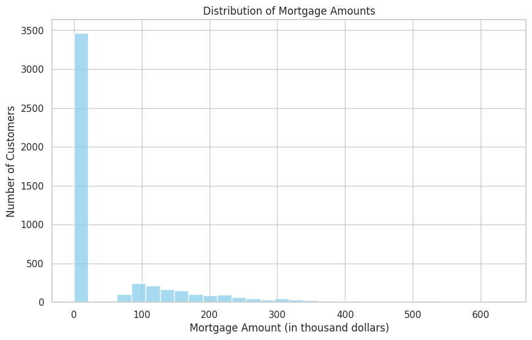

```python
#Q1: What is the distribution of mortgage attribute? Are there any noticeable patterns or outliers in the distribution?
#Knowing more about the "mortgage" attribute data pattern will help me to understand customer's financial engagement with housing loans

# The histogram shows the frequency of different mortgage amounts.
# Set plot style
sns.set(style='whitegrid')

# Plot histogram
plt.figure(figsize=(10,6))
sns.histplot(data['Mortgage'], bins=30, kde=False, color='skyblue')
plt.title('Distribution of Mortgage Amounts')
plt.xlabel('Mortgage Amount (in thousand dollars)')
plt.ylabel('Number of Customers')
plt.show()
```

**Q2: How many customers have credit cards?**

```
Number of Customers with and without Credit Cards:
CreditCard
0    3530
1    1470
Name: count, dtype: int64

Total Customers: 5000
Customers with Credit Cards: 1470 (29.40%)
Customers without Credit Cards: 3530 (70.60%)
```

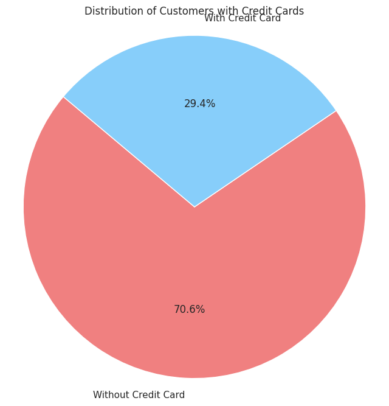

```python
# Count of customers with credit cards
credit_card_counts = data_original['CreditCard'].value_counts()

print("\nNumber of Customers with and without Credit Cards:")
print(credit_card_counts)

# Percentage of customers with credit cards
total_customers = data_original.shape[0]
customers_with_cc = credit_card_counts[1]
percentage_with_cc = (customers_with_cc / total_customers) * 100

print(f"\nTotal Customers: {total_customers}")
print(f"Customers with Credit Cards: {customers_with_cc} ({percentage_with_cc:.2f}%)")
print(f"Customers without Credit Cards: {credit_card_counts[0]} ({100 - percentage_with_cc:.2f}%)")

# Pie chart visualization
labels = ['Without Credit Card', 'With Credit Card']
sizes = [credit_card_counts[0], credit_card_counts[1]]
colors = ['lightcoral', 'lightskyblue']

plt.figure(figsize=(8, 8))
plt.pie(sizes, labels=labels, colors=colors, autopct='%1.1f%%', startangle=140)
plt.title('Distribution of Customers with Credit Cards')
plt.axis('equal')  # Equal aspect ratio ensures that pie is drawn as a circle.
plt.show()
```

**Q3: What are the attributes that have a strong correlation with the target attribute (personal loan)?**

```
Correlation of Features with Personal Loan:
Personal_Loan         1.000000
Income                0.502462
CCAvg                 0.366889
CD_Account            0.316355
Mortgage              0.142095
Education             0.136722
Family                0.061367
Securities_Account    0.021954
Online                0.006278
CreditCard            0.002802
ZIPCode              -0.002974
Age                  -0.007726
Experience           -0.008304
ID                   -0.024801
Name: Personal_Loan, dtype: float64
```

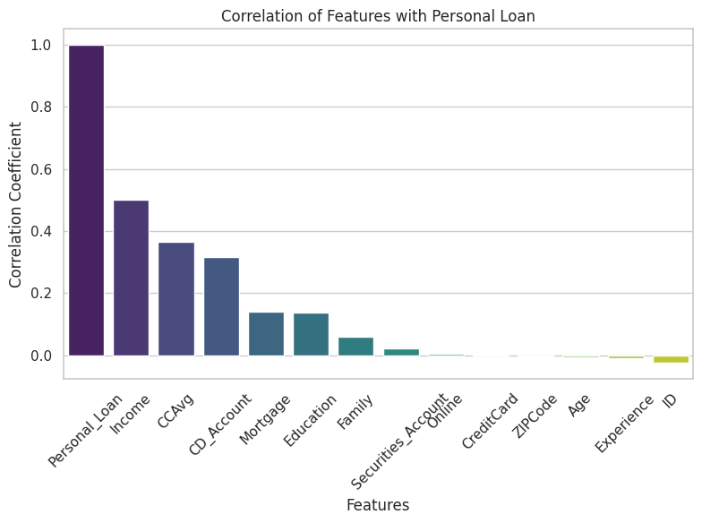

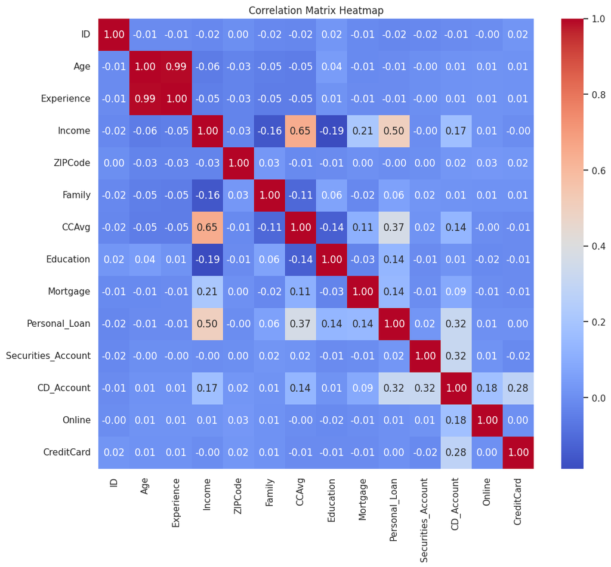

```python
# Compute the correlation matrix
corr_matrix = data_original.corr()

# Extract correlations with 'Personal_Loan'
personal_loan_corr = corr_matrix['Personal_Loan'].sort_values(ascending=False)

print("\nCorrelation of Features with Personal Loan:")
print(personal_loan_corr)

# Plotting the correlations
plt.figure(figsize=(8, 6))
sns.barplot(x=personal_loan_corr.index, y=personal_loan_corr.values, palette='viridis')
plt.title('Correlation of Features with Personal Loan')
plt.xlabel('Features')
plt.ylabel('Correlation Coefficient')
plt.xticks(rotation=45)
plt.tight_layout()
plt.show()

# Heatmap of the correlation matrix (optional, for more detailed analysis)
plt.figure(figsize=(12, 10))
sns.heatmap(corr_matrix, annot=True, fmt=".2f", cmap='coolwarm')
plt.title('Correlation Matrix Heatmap')
plt.show()
```

**Q4: How does a customer's interest in purchasing a loan vary with their age?**

```
Personal Loan Acceptance Rates by Age Group:
           count  sum  Acceptance_Rate
Age_Group
20-30        488   49        10.040984
31-40       1247  127        10.184443
41-50       1257  117         9.307876
51-60       1334  118         8.845577
61+          674   69        10.237389
```

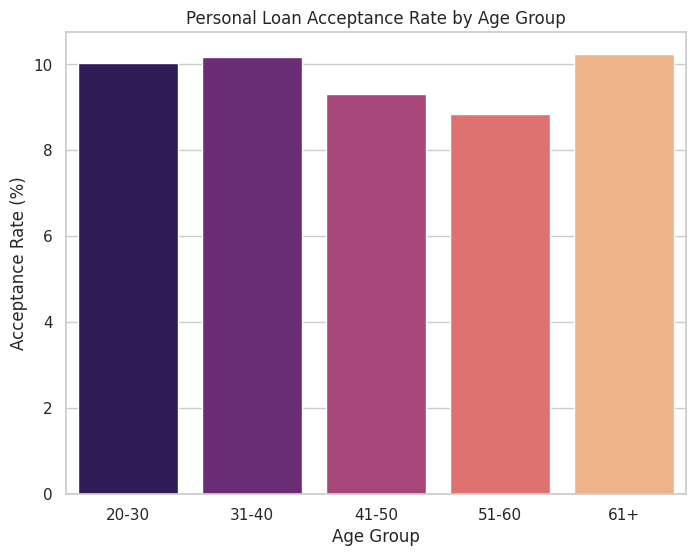

```python
# Adding an 'Age Group' column
bins = [0, 30, 40, 50, 60, np.inf]
labels = ['20-30', '31-40', '41-50', '51-60', '61+']
data_original['Age_Group'] = pd.cut(data_original['Age'], bins=bins, labels=labels, right=False)

# Calculating acceptance rates per age group
age_group_loan = data_original.groupby('Age_Group')['Personal_Loan'].agg(['count', 'sum'])
age_group_loan['Acceptance_Rate'] = (age_group_loan['sum'] / age_group_loan['count']) * 100

print("\nPersonal Loan Acceptance Rates by Age Group:")
print(age_group_loan[['count', 'sum', 'Acceptance_Rate']])

# Bar plot of acceptance rates
plt.figure(figsize=(8, 6))
sns.barplot(x=age_group_loan.index, y=age_group_loan['Acceptance_Rate'], palette='magma')
plt.title("Personal Loan Acceptance Rate by Age Group")
plt.xlabel("Age Group")
plt.ylabel("Acceptance Rate (%)")
plt.show()
```

**Q5: How does a customer's interest in purchasing a loan vary with their education?**

```
Personal Loan Acceptance Rates by Education Level:
                       count  sum  Acceptance_Rate
Education_Level
Advanced/Professional   1501  205        13.657562
Graduate                1403  182        12.972202
Undergrad               2096   93         4.437023
```

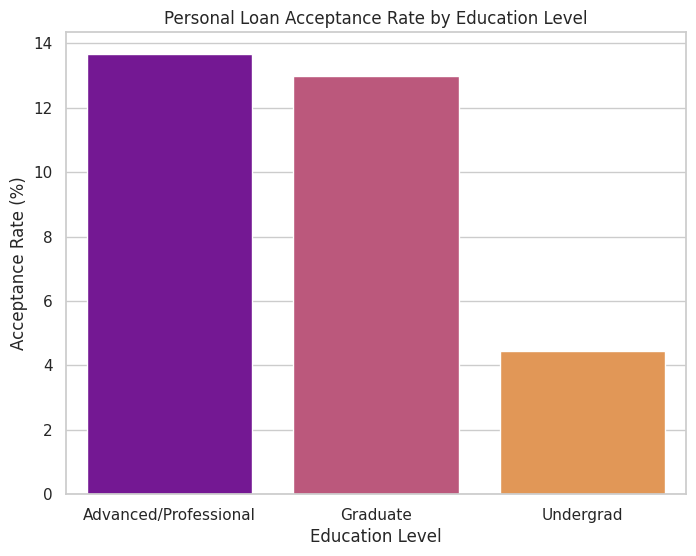

```python
# Mapping education levels to labels
education_mapping = {1: 'Undergrad', 2: 'Graduate', 3: 'Advanced/Professional'}
data_original['Education_Level'] = data_original['Education'].map(education_mapping)

# Calculating acceptance rates per education level
education_loan = data_original.groupby('Education_Level')['Personal_Loan'].agg(['count', 'sum'])
education_loan['Acceptance_Rate'] = (education_loan['sum'] / education_loan['count']) * 100

print("\nPersonal Loan Acceptance Rates by Education Level:")
print(education_loan[['count', 'sum', 'Acceptance_Rate']])

# Bar plot of acceptance rates
plt.figure(figsize=(8, 6))
sns.barplot(x=education_loan.index, y=education_loan['Acceptance_Rate'], palette='plasma')
plt.title("Personal Loan Acceptance Rate by Education Level")
plt.xlabel("Education Level")
plt.ylabel("Acceptance Rate (%)")
plt.show()
```

**Encoding Categorical Variables**

```python
# List of categorical variables
categorical_vars = ['Family', 'Education', 'Securities_Account', 'CD_Account', 'Online', 'CreditCard']

# Ensure that categorical variables are of type 'category'
for var in categorical_vars:
    data[var] = data[var].astype('category')
```

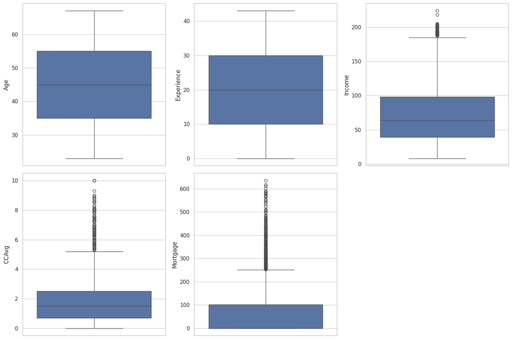

```python
# Outlier Detection and Handling

# Plotting boxplots to check for outliers
numerical_features = ['Age', 'Experience', 'Income', 'CCAvg', 'Mortgage']

plt.figure(figsize=(15, 10))
for i, feature in enumerate(numerical_features, 1):
    plt.subplot(2, 3, i)
    sns.boxplot(y=feature, data=data)
    plt.tight_layout()
plt.show()
```

# Age Observations:

The minimum age is 23, maximum age is 67, with an average of 45 years. The data shows a slight tendency towards a uniform distribution. The highest concentration of clients falls within the 58-60 years old range. Additionally, there are notable peaks in the age groups of 30-32, 38-40, 44-46, and 52-54 years old. No outliers are detected in the dataset.

# Experience Observations

1. The Experience variable ranges from 0 to 43 years, with a mean of approximately 20 years.
2. The distribution of data suggests a nearly uniform pattern, exhibiting peaks around 12-14 years and 28-30 years.
3. No outliers are observed in the dataset.

# Income Observations

# CCAvg Observations

# Mortgage Observations

**Feature Scaling**

```python
# List of numerical variables
numerical_vars = ['Age', 'Experience', 'Income', 'CCAvg', 'Mortgage']

# Initialize the scaler
scaler = StandardScaler()

# Fit and transform the numerical variables
data[numerical_vars] = scaler.fit_transform(data[numerical_vars])
```

**Exploratory Data Analysis (EDA)**

#### **Target Variable Distribution**

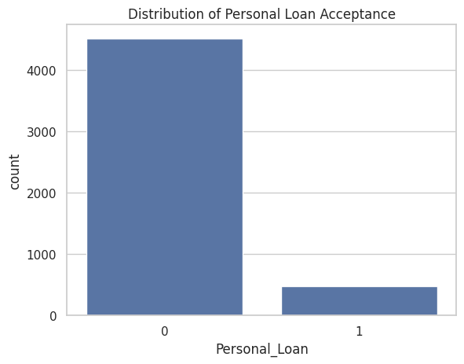

```python
# Countplot for Personal Loan acceptance
sns.countplot(x='Personal_Loan', data=data)
plt.title('Distribution of Personal Loan Acceptance')
plt.show()
```

**Correlation Matrix**

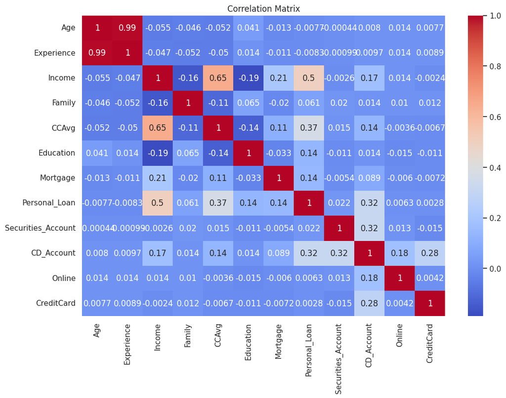

```python
# Compute correlation matrix
corr_matrix = data.corr()

# Plot the heatmap
plt.figure(figsize=(12, 8))
sns.heatmap(corr_matrix, annot=True, cmap='coolwarm')
plt.title('Correlation Matrix')
plt.show()
```

**Pairplot**

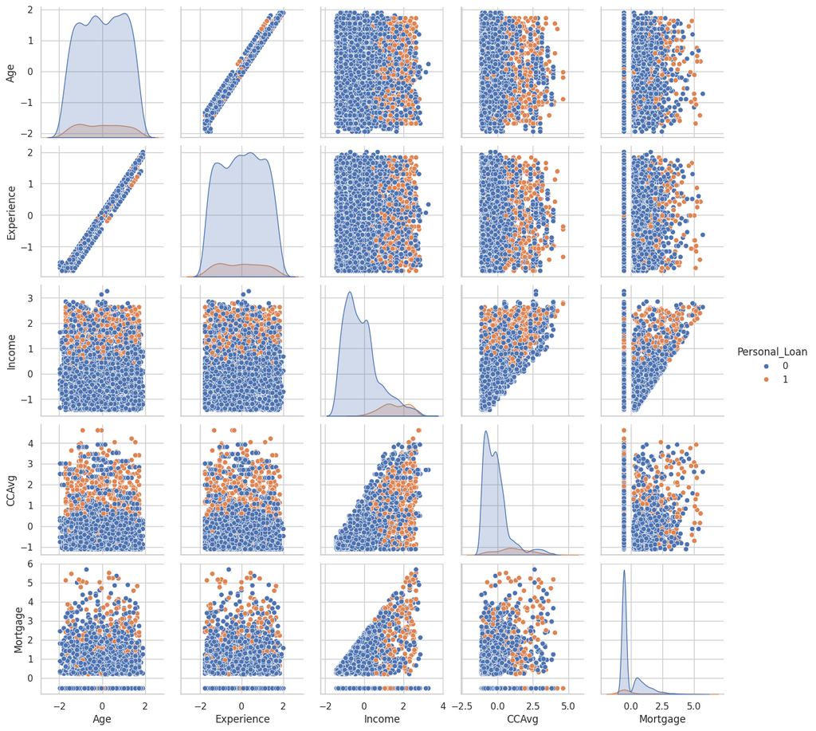

```python
# Pairplot to visualize relationships
sns.pairplot(data, hue='Personal_Loan', vars=numerical_vars)
plt.show()
```

# Observations:

**Analyzing Categorical Variables**

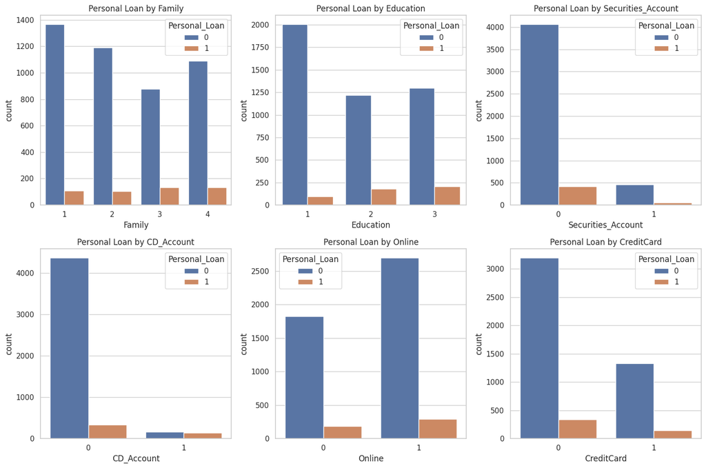

```python
# Bar plots for categorical variables
fig, axes = plt.subplots(2, 3, figsize=(15, 10))
axes = axes.flatten()

for idx, var in enumerate(categorical_vars):
    sns.countplot(x=var, hue='Personal_Loan', data=data, ax=axes[idx])
    axes[idx].set_title(f'Personal Loan by {var}')

plt.tight_layout()
plt.show()
```

**Observations:**

CCAvg: Customers with higher average credit card spending have a higher propensity.

Education: Education level impacts loan acceptance, with higher levels showing more acceptance.

Family: Family size may influence financial decisions.

```
                 Age  Experience    Income     CCAvg  Mortgage
Age         1.000000    0.993991 -0.055269 -0.052012 -0.012539
Experience  0.993991    1.000000 -0.046876 -0.049738 -0.011097
Income     -0.055269   -0.046876  1.000000  0.645984  0.206806
CCAvg      -0.052012   -0.049738  0.645984  1.000000  0.109905
Mortgage   -0.012539   -0.011097  0.206806  0.109905  1.000000
```

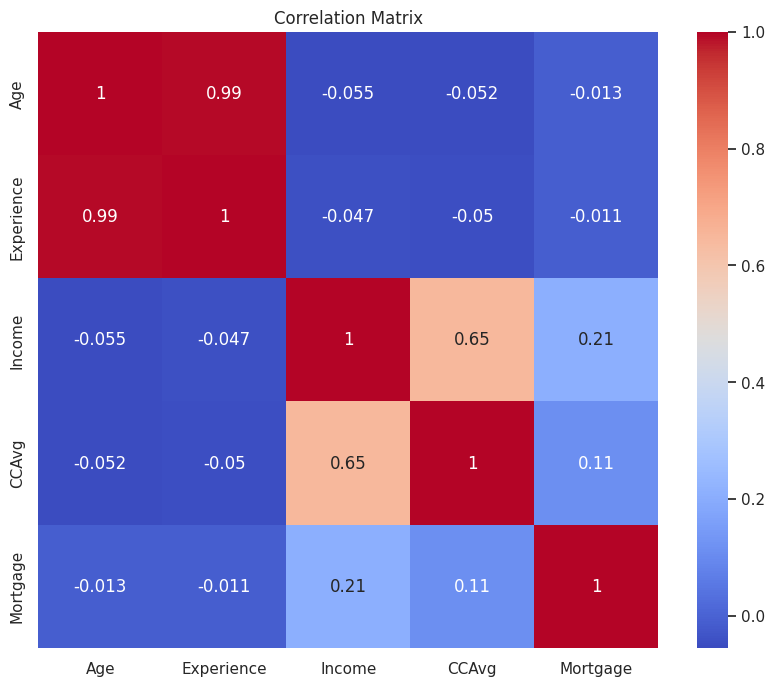

```python
#To determine the strength and direction of relationships between variables - Age, Experience, Income, CCAvg and Mortgage
import matplotlib.pyplot as plt

# Assuming your DataFrame is named df

# Calculate the correlation matrix
corr_matrix = data[['Age', 'Experience', 'Income', 'CCAvg', 'Mortgage']].corr()

# Display the correlation matrix
print(corr_matrix)

# Visualize the correlation matrix
plt.figure(figsize=(10,8))
sns.heatmap(corr_matrix, annot=True, cmap='coolwarm')
plt.title('Correlation Matrix')
plt.show()
```

#### Observations:

#### Interpretation:

#### **Age and Experience**:

#### There is a strong positive correlation.

#### Insight: High correlation confirms that as people age, they accumulate more professional experience.

### **Income with Other Variables**:

#### **Insight**: Could suggest a lifestyle of higher spending and borrowing.

**Splitting the Data**

```python
# Define feature matrix X and target vector y
X = data.drop('Personal_Loan', axis=1)
y = data['Personal_Loan']

# Convert categorical variables into dummy/indicator variables
X = pd.get_dummies(X, drop_first=True)

# Split into training and test sets (70% train, 30% test)
X_train, X_test, y_train, y_test = train_test_split(X, y, test_size=0.3, random_state=42, stratify=y)
```

## Model Building

**Logistic Regression**

```python
# Initialize the logistic regression model
logreg = LogisticRegression()

# Fit the model
logreg.fit(X_train, y_train)

# Predict on the test set
y_pred_logreg = logreg.predict(X_test)
```

**Decision Tree Classifier**

```python
# Initialize the decision tree classifier
dtree = DecisionTreeClassifier(random_state=42)

# Fit the model
dtree.fit(X_train, y_train)

# Predict on the test set
y_pred_dtree = dtree.predict(X_test)
```

### Model Evaluation Criterion

**Evaluation Metrics Function**

```python
def evaluate_model(y_true, y_pred, model_name):
    print(f"---{model_name}---")
    print("Accuracy:", accuracy_score(y_true, y_pred))
    print("\nClassification Report:\n", classification_report(y_true, y_pred))
    # Confusion Matrix
    cm = confusion_matrix(y_true, y_pred)
    sns.heatmap(cm, annot=True, fmt='d', cmap='Blues')
    plt.title(f'{model_name} Confusion Matrix')
    plt.xlabel('Predicted')
    plt.ylabel('Actual')
    plt.show()
```

**Evaluate Logistic Regression**

```
---Logistic Regression---
Accuracy: 0.962

Classification Report:
               precision    recall  f1-score   support

           0       0.97      0.99      0.98      1356
           1       0.89      0.69      0.78       144

    accuracy                           0.96      1500
   macro avg       0.93      0.84      0.88      1500
weighted avg       0.96      0.96      0.96      1500
```

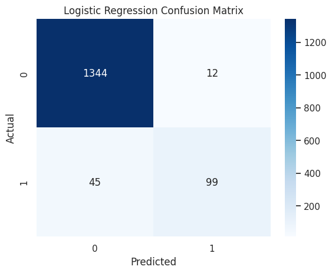

```python
evaluate_model(y_test, y_pred_logreg, "Logistic Regression")
```

**Class 0 Means:**

## Did Not Accept Personal Loan

**Class 1 Means:**

## Accepted Personal Loan

**Observation**

**Interpreting Each Metric in the Context Logistic Regression Model**

Class 0 (Did Not Accept Personal Loan) Precision: 0.97

Meaning: Of all the customers predicted to not accept the personal loan, 97% actually did not accept it.

Recall: 0.99

Meaning: Of all the customers who actually did not accept the personal loan, 99% were correctly identified by the model.

F1-score: 0.98

Meaning: The model has a high F1-score for class 0, indicating strong performance in both precision and recall.

Support: 1356

Meaning: There were 1,356 customers in the test set who did not accept the personal loan.

Class 1 (Accepted Personal Loan) Precision: 0.89

Meaning: Of all the customers predicted to accept the personal loan, 89% actually accepted it.

Recall: 0.69

Meaning: Of all the customers who actually accepted the personal loan, 69% were correctly identified by the model.

F1-score: 0.78

Meaning: The F1-score is lower for class 1, indicating that the model is less effective at predicting loan acceptance compared to non-acceptance.

Support: 144

Meaning: There were 144 customers in the test set who accepted the personal loan.

**Interpretation:** True Negatives (TN): 1,344

Correctly predicted customers who did not accept the loan.

False Positives (FP): 12

Customers predicted to accept the loan but did not.

False Negatives (FN): 45

Customers who accepted the loan but were predicted to not accept.

True Positives (TP): 99

Correctly predicted customers who accepted the loan.

**Model Strengths:**

High precision and recall for class 0 - customers Did Not Accept Personal Loan, indicating strong performance in predicting customers who will not accept the loan.

**Model Weaknesses:**

Moderate precision and recall for class 1- customers Accept Personal Loan, suggesting room for improvement in identifying customers who will accept the loan.

**Evaluate Decision Tree**

```
---Decision Tree---
Accuracy: 0.9826666666666667

Classification Report:
               precision    recall  f1-score   support

           0       0.99      0.99      0.99      1356
           1       0.89      0.94      0.91       144

    accuracy                           0.98      1500
   macro avg       0.94      0.96      0.95      1500
weighted avg       0.98      0.98      0.98      1500
```

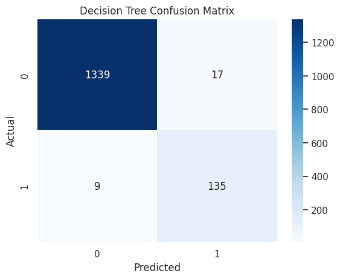

```python
evaluate_model(y_test, y_pred_dtree, "Decision Tree")
```

**Observation**

**True Negatives (TN = 1,339):**

These are customers who did not accept the personal loan, and the model correctly predicted they wouldn't.

Represents correct rejections.

False Positives (FP = 17):

These are customers who did not accept the personal loan, but the model incorrectly predicted that they would.

Represents overestimation by the model; can lead to unnecessary marketing efforts.

False Negatives (FN = 9):

These are customers who did accept the personal loan, but the model failed to predict this.

Represents missed opportunities; the model underestimated these customers.

True Positives (TP = 135):

These are customers who did accept the personal loan, and the model correctly predicted they would.

Represents successful identification of potential customers.

## Model Performance Improvement

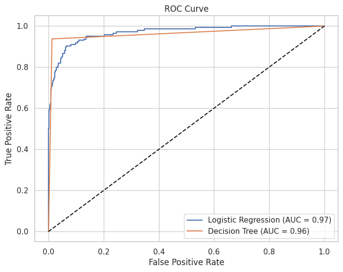

```python
# Compute predicted probabilities
y_prob_logreg = logreg.predict_proba(X_test)[:, 1]
y_prob_dtree = dtree.predict_proba(X_test)[:, 1]

# Compute ROC curve and AUC

fpr_logreg, tpr_logreg, _ = roc_curve(y_test, y_prob_logreg)
roc_auc_logreg = roc_auc_score(y_test, y_prob_logreg)

fpr_dtree, tpr_dtree, _ = roc_curve(y_test, y_prob_dtree)
roc_auc_dtree = roc_auc_score(y_test, y_prob_dtree)

# Plot ROC curves
plt.figure(figsize=(8, 6))
plt.plot(fpr_logreg, tpr_logreg, label=f'Logistic Regression (AUC = {roc_auc_logreg:.2f})')
plt.plot(fpr_dtree, tpr_dtree, label=f'Decision Tree (AUC = {roc_auc_dtree:.2f})')
plt.plot([0, 1], [0, 1], 'k--')
plt.title('ROC Curve')
plt.xlabel('False Positive Rate')
plt.ylabel('True Positive Rate')
plt.legend()
plt.show()
```

**AUC Interpretation::**

The model has an AUC of 0.97 for Logistic Regression and 0.96 for Decision Tree, indicating the model is very good in distinguishing between the two classes - Class 0 and Class 1.

**Logistic Regression Coefficients**

```python
# Create a DataFrame for coefficients
coefficients = pd.DataFrame({
    'Feature': X.columns,
    'Coefficient': logreg.coef_[0]
})

# Sort by absolute value of coefficients
coefficients['Abs_Coeff'] = coefficients['Coefficient'].abs()
coefficients.sort_values(by='Abs_Coeff', ascending=False, inplace=True)

# Display the top 10 features
print("Top 10 Features Influencing Loan Acceptance (Logistic Regression):")
print(coefficients.head(10)[['Feature', 'Coefficient']])
```

```
Top 10 Features Influencing Loan Acceptance (Logistic Regression):
                 Feature  Coefficient
9            Education_3     3.348069
8            Education_2     3.253012
11          CD_Account_1     3.063935
2                 Income     2.500949
6               Family_3     1.692436
7               Family_4     1.406235
13          CreditCard_1    -0.794274
12              Online_1    -0.609709
10  Securities_Account_1    -0.569829
3                  CCAvg     0.335864
```

The Logistic Regression Coefficients shows that Income, CCAvg are showing as Top 10 Features.

**Decision Tree Feature Importance**

```python
# Create a DataFrame for feature importances
feature_importances = pd.DataFrame({
    'Feature': X.columns,
    'Importance': dtree.feature_importances_
})

# Sort by importance
feature_importances.sort_values(by='Importance', ascending=False, inplace=True)

# Display the top 10 features
print("Top 10 Features Influencing Loan Acceptance (Decision Tree):")
print(feature_importances.head(10))
```

```
Top 10 Features Influencing Loan Acceptance (Decision Tree):
         Feature  Importance
2         Income    0.420421
8    Education_2    0.184001
9    Education_3    0.117514
7       Family_4    0.083364
6       Family_3    0.070002
3          CCAvg    0.063837
4       Mortgage    0.015956
0            Age    0.013605
11  CD_Account_1    0.012278
1     Experience    0.012241
```

Decision Tree Feature Importance:

**Hyperparameter Tuning**

**Decision Tree Hyperparameter Tuning**

```
Best Parameters for Decision Tree: {'criterion': 'entropy', 'max_depth': 7, 'min_samples_split': 10}
---Tuned Decision Tree---
Accuracy: 0.982

Classification Report:
               precision    recall  f1-score   support

           0       0.99      0.99      0.99      1356
           1       0.89      0.92      0.91       144

    accuracy                           0.98      1500
   macro avg       0.94      0.96      0.95      1500
weighted avg       0.98      0.98      0.98      1500
```

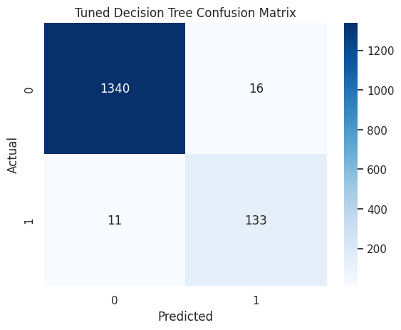

```python
# Define parameter grid for Decision Tree
param_grid = {
    'max_depth': [3, 5, 7, 9, None],
    'min_samples_split': [2, 5, 10],
    'criterion': ['gini', 'entropy']
}

# Initialize GridSearchCV
grid_search = GridSearchCV(dtree, param_grid, cv=5, scoring='accuracy')

# Fit the model
grid_search.fit(X_train, y_train)

# Best parameters
print("Best Parameters for Decision Tree:", grid_search.best_params_)

# Best estimator
best_dtree = grid_search.best_estimator_

# Predict with best estimator
y_pred_best_dtree = best_dtree.predict(X_test)

# Evaluate
evaluate_model(y_test, y_pred_best_dtree, "Tuned Decision Tree")
```

**Logistic Regression Hyperparameter Tuning**

```
Best Parameters for Logistic Regression: {'C': 0.01, 'penalty': 'none', 'solver': 'saga'}
---Tuned Logistic Regression---
Accuracy: 0.9606666666666667

Classification Report:
               precision    recall  f1-score   support

           0       0.97      0.99      0.98      1356
           1       0.86      0.71      0.78       144

    accuracy                           0.96      1500
   macro avg       0.91      0.85      0.88      1500
weighted avg       0.96      0.96      0.96      1500
```

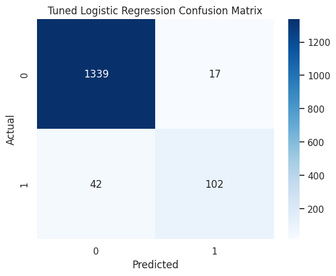

```python
# Define parameter grid for Logistic Regression
param_grid_lr = {
    'C': [0.01, 0.1, 1, 10],
    'penalty': ['l1', 'l2', 'elasticnet', 'none'],
    'solver': ['liblinear', 'saga']
}

# Initialize GridSearchCV
grid_search_lr = GridSearchCV(logreg, param_grid_lr, cv=5, scoring='accuracy')

# Fit the model
grid_search_lr.fit(X_train, y_train)

# Best parameters
print("Best Parameters for Logistic Regression:", grid_search_lr.best_params_)

# Best estimator
best_logreg = grid_search_lr.best_estimator_

# Predict with best estimator
y_pred_best_logreg = best_logreg.predict(X_test)

# Evaluate
evaluate_model(y_test, y_pred_best_logreg, "Tuned Logistic Regression")
```

**Interpretation and Recommendations** **Identifying Significant Attributes**

From the feature importance and coefficients, we can identify:

Income: Higher income customers are more likely to accept personal loans.

CCAvg: Customers with higher average credit card spending have a higher propensity.

Education: Education level impacts loan acceptance, with higher levels showing more acceptance.

Family: Family size may influence financial decisions.

**Target Customer Segments**

Based on the models:

High-Income Earners: Focus marketing efforts on customers with higher incomes.

Active Credit Users: Customers with high credit card usage.

Educated Professionals: Those with graduate or advanced degrees.

## Actionable Insights and Business Recommendations

- What recommedations would you suggest to the bank?

# Business Understanding and Model Conclusion for AllLife Bank

**Goal:** AllLife Bank aims to convert liability customers into loan customers. To achieve this, the bank needs to understand the relationships between the variables in the data and derive actionable insights.

**Important Measures:**

**Important Features:**

By leveraging the insights from this model, All Life Bank can effectively target potential loan customers, minimize marketing costs, and increase loan acceptance rates. This targeted approach helps the bank achieve its goal of converting liability customers into loan customers more efficiently.